# Investigation of exponential distribution in R

# By: Mahesh Dave

This project investigates the exponential distribution in R and compares it with the Central Limit Theorem. The lambda for the distribution was set to 0.2. The theoritical mean of this distribution was calculated by taking 1/lambda and the theoritical standard deviation was also calculated by taking 1/lambda. The central limit theorem was analyzed using means for 40 exponentials out of a 1000 data points. The simulated mean and variance were compared to the theoritcal mean and variance.

### Simulation of data

```r
th.lambda <- 0.2
th.std <- 1/th.lambda
th.mean <- 1/th.lambda
th.var <- th.std^2
n <- 1000
set.seed(100)
thdata <- rexp(n,th.lambda)
```

Histogram of simulated 1000 points

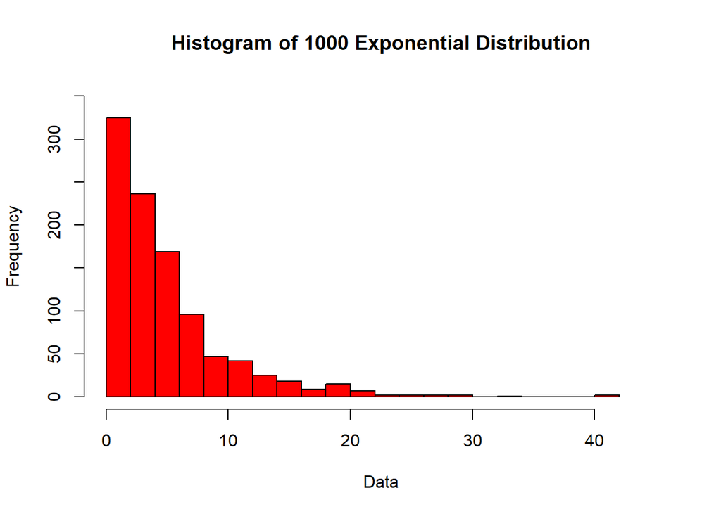

```r
hist(thdata,breaks = 25,col="red",main="Histogram of 1000 Exponential Distribution",xlab="Data",ylim = c(0,350),xlim = c(0,45))
```

The mean of the above distribution is:

```r
th.mean
```

```
## [1] 5
```

The variation of the above distribution is:

```r
th.var
```

```
## [1] 25
```

### MEAN

Now we will plot 25 values of means of a sample size 40 drawn from the theorical data without replacement.

```r
smatrix <- matrix(sample(thdata,40*25),40,25)
smeans <- apply(smatrix,2,mean)
svar <- apply(smatrix,2,var)
```

This is the histogram of 25 means collected from 1000 data points without replacement.

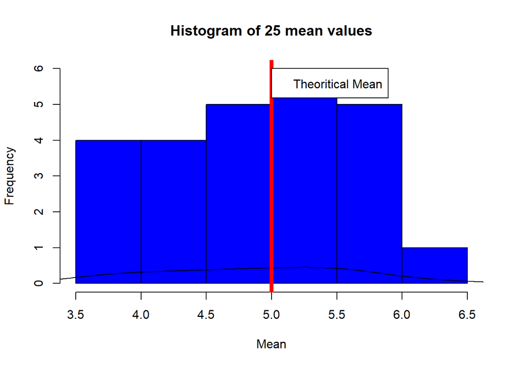

```r
hist(smeans,breaks = 6,main="Histogram of 25 mean values",xlab="Mean",col = "blue")
lines(density(smeans,adjust = 1))
abline(v=th.mean,col="red",lwd=5)
legend(5,6,"Theoritical Mean",col = "red")
```

As you can see this mean is centered around the theoritical mean which is 5

### VARIANCE

Now we will plot 25 values of variations of a sample size 40 drawn from the theoritical data without replacement.

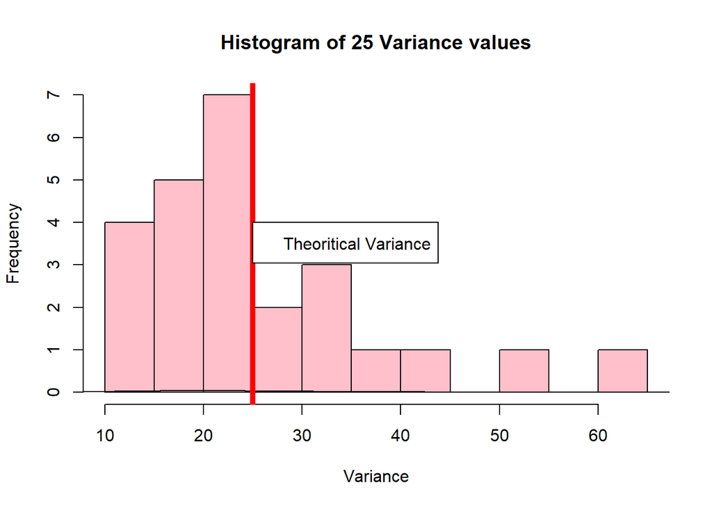

```r
hist(svar,breaks = 10,main="Histogram of 25 Variance values",xlab="Variance",col = "pink")
lines(density(svar,adjust = 1))
abline(v=th.var,col="red",lwd=5)
legend(25,4,"Theoritical Variance",col = "red")
```

As you can see this variance is centered around the theoritical variance which is 25